# 第7课 统计量和检验结果的表格化 习题

顶刊研习社

Li Zongzhang

2023-10-20

# 1 习题1

1.1 创建一个gt对象的主题函数，自定义表格的全局属性如标题、列标签字体大小，行高、内部横线宽度，样式等。

提示：先调用mtcars，创建gt(), 自定义表格主题，运行代码，对主题满意后，再创建主题函数。不要直接创建主题函数，因为这样会看不到效果。

1.2 从数据框ggplot2::msleep中筛选出8行, 6列， 保存为数据框mydata。将1.1中创建的主题应用到数据框mydata。

1.3 从数据框dplyr::starwars中筛选出8行, 6列，保存为数据框mydata。将1.1中创建的主题应用到数据框mydata。

# 2 习题2

2.1 创建一个项目，在该项目中创建一个代码文件。

2.2 调用数据gtsummary::trial, 查看其帮助功能。

2.3 报告trial中所有变量的Table1（形式如下图）。

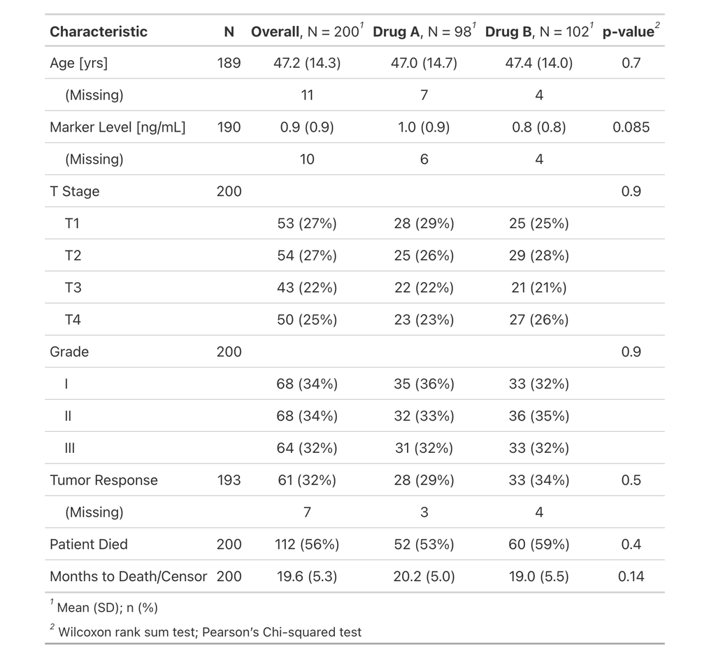

# 3 习题3

数据文件：stroke.xlsx

变量含义：stroke.xlsx的sheet2中有说明

3.1 创建一个项目，在该项目中创建一个代码文件，该项目中存放有stroke.xlsx。

3.2 将stroke.xlsx的sheet1导入到R Studio中，保存为数据框stroke。

3.3 报告stroke中所有变量的Table1。